# Hypothesis testing

MACS 33001 University of Chicago

$$\newcommand{\E}{\mathrm{E}} \newcommand{\Var}{\mathrm{Var}} \newcommand{\Cov}{\mathrm{Cov}} \newcommand{\se}{\text{se}} \newcommand{\Lagr}{\mathcal{L}} \newcommand{\lagr}{\mathcal{l}}$$

## Hypothesis testing

- Default theory
- Null vs. alternative hypothesis
- Sufficient evidence to reject the null hypothesis?

## Hypothesis testing

- Partition the parameter space $\Theta$ into two disjoint sets $\Theta_0$ and $\Theta_1$
- Test

  $$H_0: \theta \in \Theta_0 \quad \text{versus} \quad H_1: \theta \in \Theta_1$$
- Let $X$ be a random variable and let $\chi$ be the range of $X$
- Find a subset of outcomes $R \subset \chi$ (rejection region)
  - If $X \subset R$, reject the null
  - Otherwise do not reject the null
- Rejection region $R$

  $$R = \left\{ x: T(x) > c \right\}$$
  - Test statistic
  - Critical value

## Types of errors

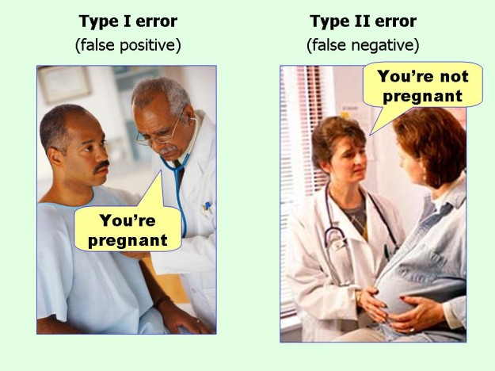

## Power function

$$\beta(\theta) = \Pr_\theta (X \in R)$$

- The size of a test

  $$\alpha = \text{sup}_{\theta \in \Theta_0} \beta(\theta)$$
- Level $\alpha$

## Sided tests

- Two-sided test

  $$H_0: \theta = \theta_0 \quad \text{versus} \quad H_1: \theta \neq \theta_0$$
- One-sided test

  $$H_0: \theta \leq \theta_0 \quad \text{versus} \quad H_1: \theta > \theta_0$$

  or

  $$H_0: \theta \geq \theta_0 \quad \text{versus} \quad H_1: \theta < \theta_0$$

## Example hypothesis test

- Let $X_1, \ldots, X_n \sim N(\mu, \sigma^2)$ where $\sigma$ is known

  $$H_0: \mu \leq 0 \quad \text{versus} \quad H_1: \mu > 0$$
- $\Theta_0 = (-\infty, 0]$ and $\Theta_1 = (0, \infty]$
- Consider the test

  $$\text{reject } H_0 \text{ if } T>c$$

  where $T = \bar{X}$
- Rejection region
  $$R = \left\{(x_1, \ldots, x_n): T(x_1, \ldots, x_n) > c \right\}$$
- Power function

  $$\begin{align}
  \beta(\mu) &= \Pr_\mu (\bar{X} > c) \\
  &= \Pr_\mu \left(\frac{\sqrt{n} (\bar{X} - \mu)}{\sigma} > \frac{\sqrt{n} (c - \mu)}{\sigma} \right) \\
  &= \Pr_\mu \left(Z > \frac{\sqrt{n} (c - \mu)}{\sigma} \right) \\
  &= 1 - \Phi \left( \frac{\sqrt{n} (c - \mu)}{\sigma} \right)
  \end{align}$$

## Example hypothesis test

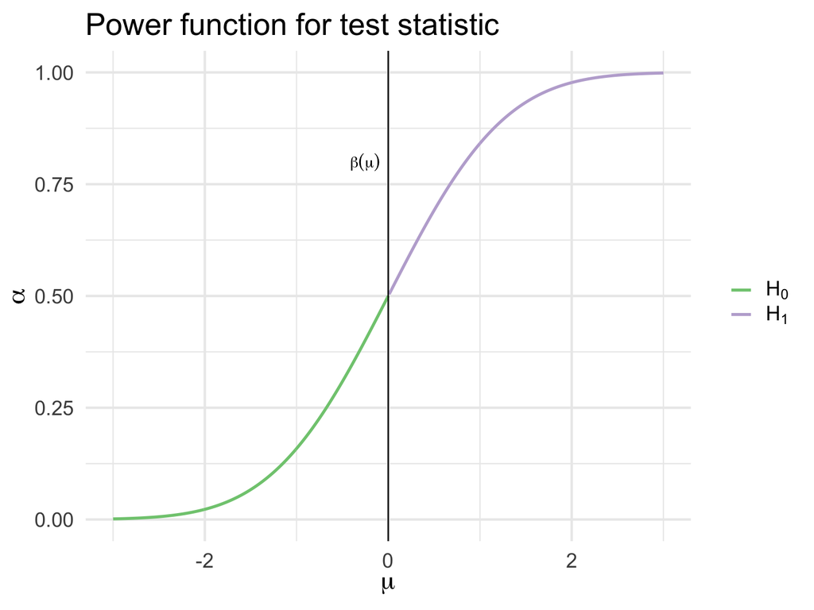

## Example hypothesis test

$$\alpha = \text{sup}_{\mu \leq 0} \beta(\mu) = \beta(0) = 1 - \Phi \left( \frac{\sqrt{n} (c)}{\sigma} \right)$$

- Solve for $c$

  $$c = \frac{\sigma \Phi^{-1} (1 - \alpha)}{\sqrt{n}}$$
- Reject $H_0$ when

  $$\bar{X} > \frac{\sigma \Phi^{-1} (1 - \alpha)}{\sqrt{n}}$$

  $$\frac{\sqrt{n}(\bar{X} - 0)}{\sigma} > z_\alpha$$
  - $z_\alpha = \Phi^{-1} (1 - \alpha)$

## Wald test

- $\theta$
- $\hat{\theta}$
- $\widehat{\se}$
- Consider testing

  $$H_0: \theta = \theta_0 \quad \text{versus} \quad H_1: \theta \neq \theta_0$$
- Assume that $\hat{\theta}$ is asymptotically Normal:

  $$\frac{\hat{\theta} - \theta_0}{\widehat{\se}} \leadsto N(0,1)$$
- Reject $H_0$ when $|W| > z_{\alpha / 2}$ where

  $$W = \frac{\hat{\theta} - \theta_0}{\widehat{\se}}$$

## Power of the Wald test

- Suppose the true value of $\theta$ is $\theta_* \neq \theta_0$
- Power $\beta(\theta_*)$

  $$1 - \Phi \left( \frac{\hat{\theta} - \theta_0}{\widehat{\se}} + z_{\alpha/2} \right) + \Phi \left( \frac{\hat{\theta} - \theta_0}{\widehat{\se}} - z_{\alpha/2} \right)$$
- Power is large if $\theta_*$ is far from $\theta_0$
- Power is large if the sample size is large

## Example: comparing two means

- Let $X_1, \ldots, X_m$ and $Y_1, \ldots, Y_n$ be two independent samples from populations with means $\mu_1, \mu_2$ respectively

  $$H_0: \delta = 0 \quad \text{versus} \quad H_1: \delta \neq 0$$

  where $\delta = \mu_1 - \mu_2$
- $\hat{\delta} = \bar{X} - \bar{Y}$

  $$\widehat{\se} = \sqrt{\frac{s_1^2}{m} + \frac{s_2^2}{n}}$$
- Size $\alpha$ Wald test rejects $H_0$ when $|W| > z_{\alpha / 2}$ where

  $$W = \frac{\hat{\delta} - 0}{\widehat{\se}} = \frac{\bar{X} - \bar{Y}}{\sqrt{\frac{s_1^2}{m} + \frac{s_2^2}{n}}}$$

## History of Student’s $t$

- William Sealy Gosset
- Beermaking
- $N=3$
- New distribution for low $N$
- Pseudonym “Student”

## Differences from the Normal Distribution

$$f(t) = \frac{\Gamma (\frac{k+1}{2})}{\sqrt{k\pi} \Gamma (\frac{k}{2}) } (1 + \frac{t^2}{k})^{-\frac{k + 1}{2}}$$

- Normal distribution always has the same shape
- Shape of the student’s $t$-distribution changes depending on the sample size

## Differences from the Normal Distribution

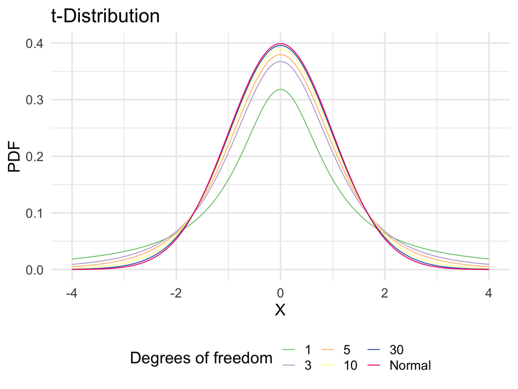

## Relationship to confidence intervals

- Wald test

  Reject $H_0: \theta = \theta_0 \quad \text{versus} \quad \theta \neq \theta_0$ if and only if $\theta_0 \notin C$ where

  $$C = (\hat{\theta} - \widehat{\se}z_{\alpha / 2}, \hat{\theta} + \widehat{\se}z_{\alpha / 2})$$
- Confidence interval: $\hat{\theta} \pm \widehat{\se} z_{\alpha/2}$
  - Check whether the null value is in the CI

## Statistical vs. scientific significance

[figure not shown]

## $p$-values

- If the test rejects at level $\alpha$ it will also reject at level $\alpha' > \alpha$
- $p$-value - smallest $\alpha$ at which the test rejects the null
- Function of power
  - Magnitude of the difference between $\theta_*$ and $\theta_0$
  - Sample size

## Interpreting $p$-values

| $p$-value | evidence |
| --- | --- |
| $< .01$ | very strong evidence against $H_0$ |
| $.01 - .05$ | strong evidence against $H_0$ |
| $.05 - .10$ | weak evidence against $H_0$ |
| $> .1$ | little or no evidence against $H_0$ |

- A large $p$-value is not strong evidence in favor of $H_0$
  - $H_0$ could be true
  - $H_0$ is false but the test has low power
- $p$-value is not $\Pr (H_0 | \text{Data})$

## Calculating $p$-values

- Suppose that the size $\alpha$ test is of the form

  $$\text{reject } H_0 \text{ if and only if } T(X_n) \geq c_\alpha$$
- Then,

  $$\text{p-value} = \text{sup}_{\theta \in \Theta_0} \Pr_\theta (T(X^n) \geq T(x^n))$$

  where $x^n$ is the observed value of $X^n$
- If $\Theta_0 = \{ \theta_0 \}$ then

  $$\text{p-value} = \Pr_{\theta_0} (T(X^n) \geq T(x^n))$$

## $p$-value for Wald test

- $w = \frac{\hat{\theta} - \theta_0}{\widehat{\se}}$
- $p$-value is given by

  $$\text{p-value} = \Pr_{\theta_0} (|W| > |w|) \approx \Pr (|Z| > |w| = 2 \Phi(-|w|)$$

  where $Z \sim N(0,1)$

## $p$-value for Wald test

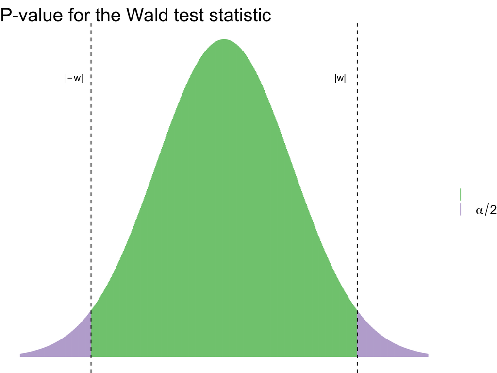

## Example: cholesterol data

- 371 individuals in a health study examining cholesterol levels (in mg/dl)
- 320 individuals have narrowing of the arteries
- 51 patients have no evidence of heart disease
- Is the mean cholesterol different in the two groups?

## $\chi^2$ distribution

- Let $Z_1, \ldots, Z_k$ be independent, standard Normals
- Let $V = \sum_{i=1}^k Z_i^2$
- $V \sim \chi_k^2$ distribution with $k$ degrees of freedom

  $$f(v) = \frac{v^{\frac{k}{2} - 1} e^{-\frac{v}{2}}}{2^{\frac{k}{2} \Gamma \left(\frac{k}{2} \right)}}$$

  for $v>0$

## $\chi^2$ distribution

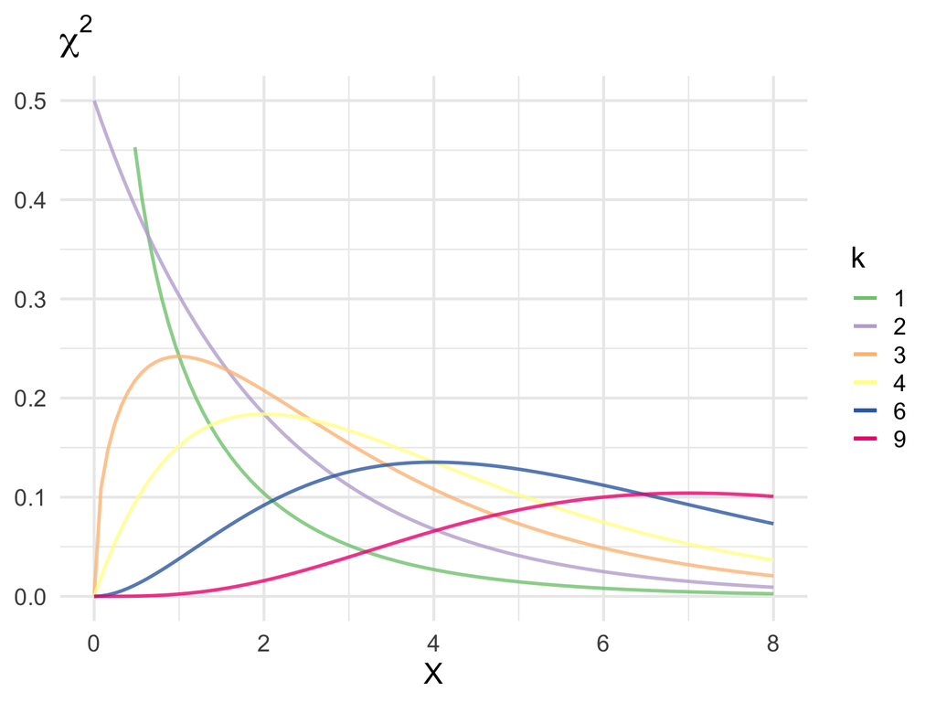

## Pearson’s $\chi^2$ test for multinomial data

- Used for multinomial data
- $X = (X_1, \ldots, X_k)$ has a multinomial $(n,p)$ distribution
- MLE is $\hat{p} = (\hat{p}_1, \ldots, \hat{p}_k) = (x_1 / n, \ldots, x_k / n)$
- $p_0 = (p_{01}, \ldots, p_{0k})$

  $$H_0: p = p_0 \quad \text{versus} \quad H_1: p \neq p_0$$
- Pearson’s $\chi^2$ statistic

  $$T = \sum_{j=1}^k \frac{(X_j - np_{0j})^2}{np_{0j}} = \sum_{j=1}^k \frac{(X_j - E_j)^2}{E_j}$$

  where $E_j = \E[X_j] = np_{0j}$ is the expected value under $H_0$

## Example: attitudes towards abortion

- $H_A$ - In a comparison of individuals, liberals are more likely to favor allowing a woman to obtain an abortion for any reason than conservatives
- $H_0$ - There is no difference in support between liberals and conservatives for allowing a woman to obtain an abortion for any reason. Any difference is the result of random sampling error.
- What if $H_0$ is correct?

## If null hypothesis is correct

| Right to Abortion | Liberal | Moderate | Conservative | Total |
| --- | --- | --- | --- | --- |
| Yes | 40.8% | 40.8% | 40.8% | 40.8% |
|  | (206.45) | (289.68) | (271.32) | (768) |
| No | 59.2% | 59.2% | 59.2% | 59.2% |
|  | (299.55) | (420.32) | (393.68) | (1113) |
| Total | 26.9% | 37.7% | 35.4% | 100% |
|  | (506) | (710) | (665) | (1881) |

## Observed data

| Right to Abortion | Liberal | Moderate | Conservative | Total |
| --- | --- | --- | --- | --- |
| Yes | 62.6% | 36.6% | 28.7% | 40.8% |
|  | (317) | (260) | (191) | (768) |
| No | 37.4% | 63.4% | 71.28% | 59.2% |
|  | (189) | (450) | (474) | (1113) |
| Total | 26.9% | 37.7% | 35.4% | 100% |
|  | (506) | (710) | (665) | (1881) |

## $\chi^2$ Test of Significance

[output not shown]

- Calculating test statistic
  - $\chi^2=\sum{\frac{(X_j - E_j)^2}{E_j}}=145.27$
  - $\text{Degrees of freedom} = (\text{number of rows}-1)(\text{number of columns-1})=2$
- Calculating $p$-value
  - $\text{p-value} = \Pr (\chi_2^2 > 145.27) = 0$

## Likelihood ratio test

- Wald test is for scalar parameter
- Generalization to vector-valued parameter
- Consider testing

  $$H_0: \theta \in \Theta_0 \quad \text{versus} \quad H_1: \theta \notin \Theta_0$$
- Likelihood ratio test statistic

  $$\lambda = 2 \log \left( \frac{\text{sup}_{\theta \in \Theta} \Lagr (\theta)}{\text{sup}_{\theta \in \Theta_0} \Lagr (\theta)} \right) = 2 \log \left( \frac{\Lagr(\hat{\theta})}{\Lagr (\hat{\theta}_0)} \right)$$
  - $\hat{\theta}$
  - $\hat{\theta}_0$

## Likelihood ratio test

- Useful when $\Theta_0$ consists of all parameter values $\theta$ such that some coordinates of $\theta$ are fixed at particular values
- $\theta = (\theta_1, \ldots, \theta_q, \theta_{q + 1}, \ldots, \theta_r)$
- $\Theta_0 = \left\{ \theta: (\theta_{q+ 1}, \ldots, \theta_r) = (\theta_{0,q+1}, \ldots, \theta_{0,r}) \right\}$
- $\lambda$
- Under $H_0: \theta \in \Theta_0$,

  $$\lambda(x^n) \leadsto \chi_{r - q, \alpha}^2$$
  - $r-q$
  - $p$-value is $\Pr (\chi_{r-q}^2 > \lambda)$
- $\theta = (\theta_1, \theta_2, \theta_3, \theta_4, \theta_5)$
  - $H_0: \theta_4 = \theta_5 = 0$
  - $5-3 = 2$ degrees of freedom

## Example: Mendel’s peas

Mendel bred peas with round yellow seeds and wrinkled green seeds. There are four types of progeny: round yellow, wrinkled yellow, round green, and wrinkled green. The number of each type is multinomial with probability $p = (p_1, p_2, p_3, p_4)$. His history of inheritance predicts that $p$ is equal to

$$p_0 \equiv \left(\frac{9}{16}, \frac{3}{16}, \frac{3}{16}, \frac{1}{16} \right)$$

- In $n = 556$ trials he observed $X = (315,101,108,32)$
- $H_0: p$
- Likelihood ratio test

## Multiple testing

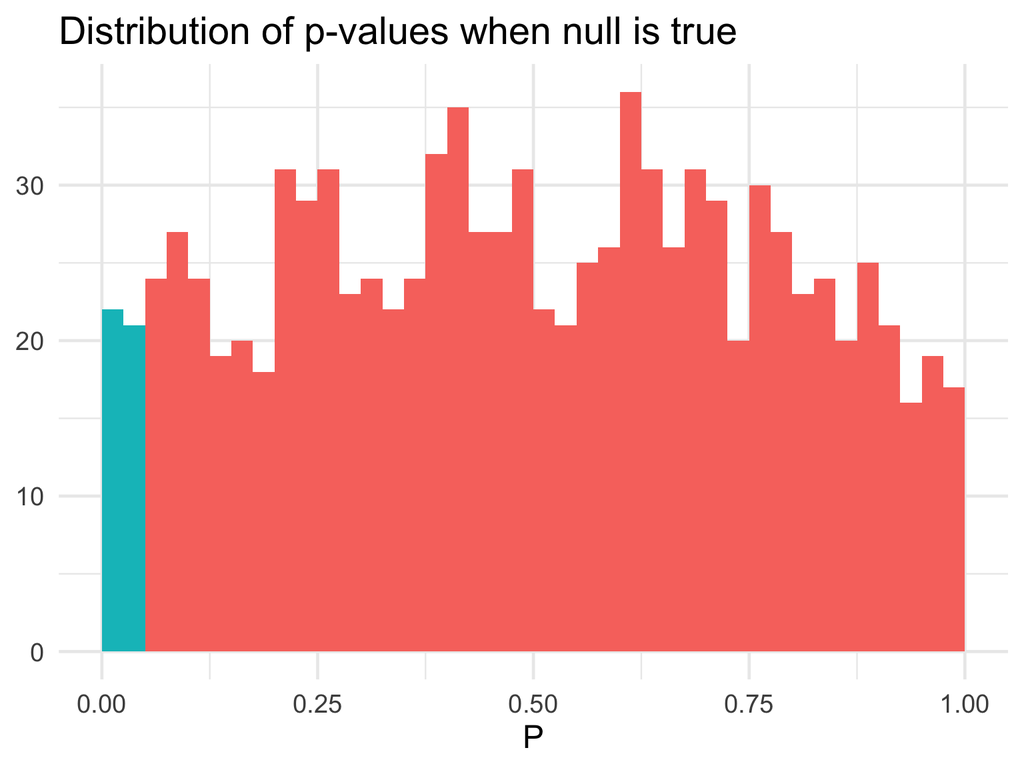

## Multiple testing

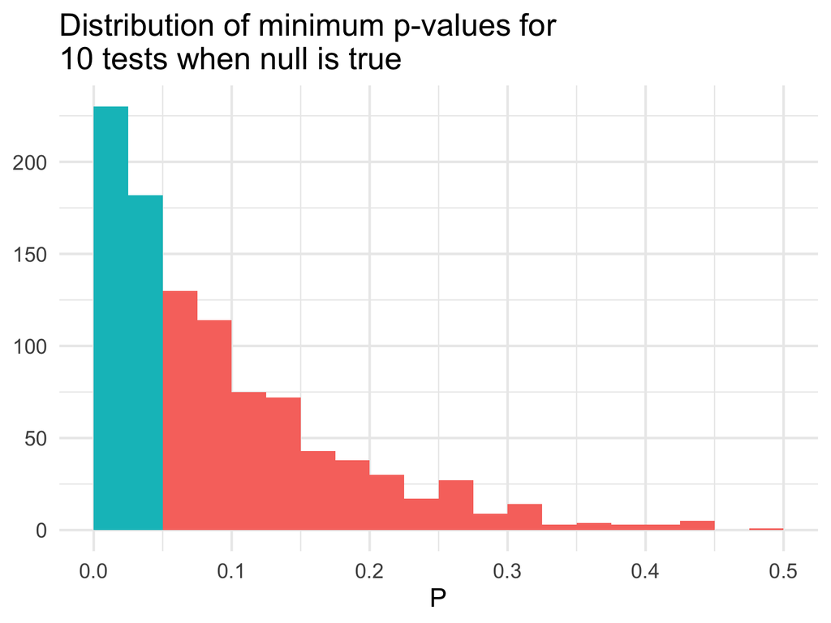

## Bonferroni correction

- Consider $m$ hypothesis tests

  $$H_{0i} \quad \text{versus} \quad H_{1i}, i = 1, \ldots, m$$
  - $P_1, \ldots, P_m$
- Given $p$-values $P_1, \ldots, P_m$, reject null hypothesis $H_{0i}$ if

  $$P_i \leq \frac{\alpha}{m}$$
- Example
  - $m=20$
  - $\alpha = 0.05$
  - Test each individual hypothesis at $\alpha = \frac{0.05}{20} = 0.0025$

## Bonferroni correction

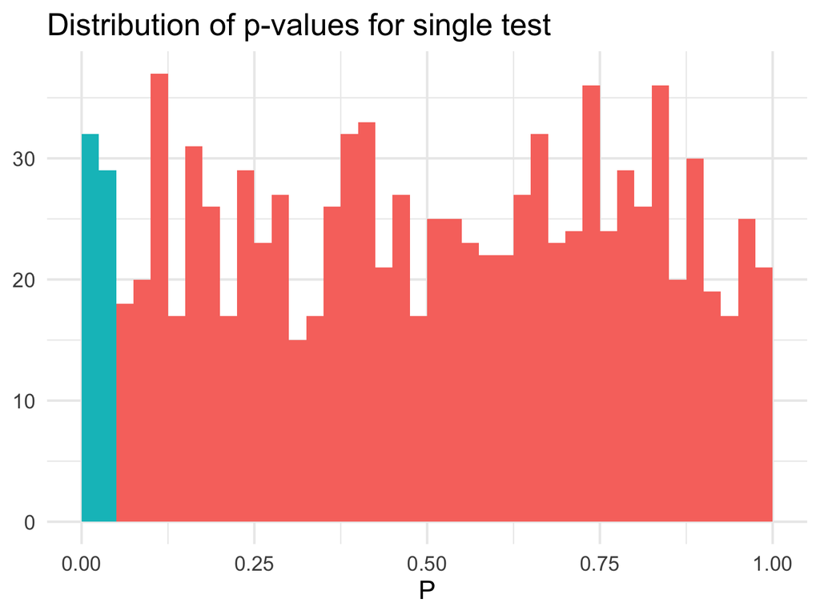

## Bonferroni correction

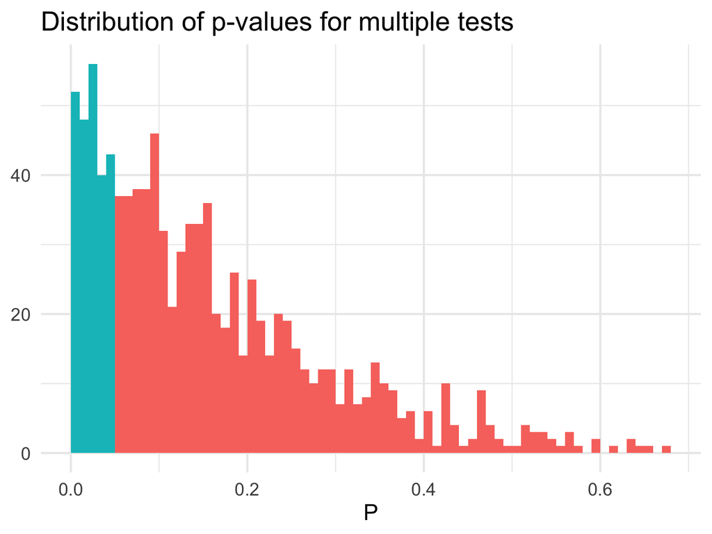

## Bonferroni correction

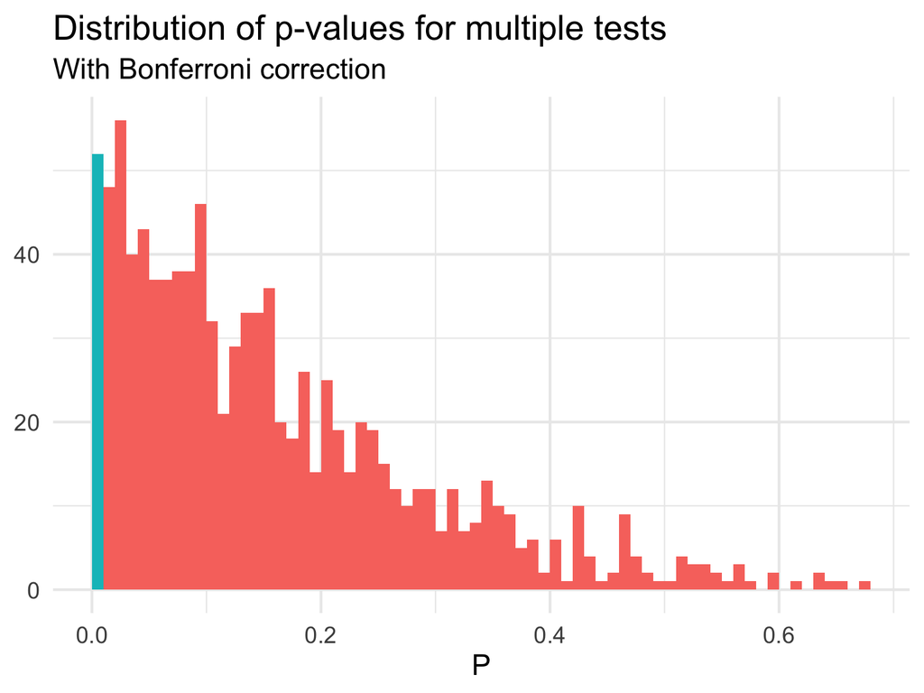